# Class 07 Machine Learning 1

Nicole Alfonso

2024-02-04

# First up, kmeans()

Demo of using kmeans() function in R. FIrst make up some data with a known structure.

```r
# We will generate random numbers
tmp <- c(rnorm(30, -3), rnorm(30, 3))
tmp
```

```
##  [1] -2.2339206 -1.5177011 -2.3895207 -3.9541927 -0.4063504 -3.0507504
##  [7] -2.6283172 -3.3572255 -3.1863535 -2.8118025 -2.0101256 -3.4649216
## [13] -2.9285242 -0.8565791 -1.6691873 -2.9005993 -4.8803814 -3.3985725
## [19] -3.9300801 -4.5701306 -5.0639526 -2.5545543 -2.5693979 -3.0356286
## [25] -2.9602581 -3.1618527 -2.1299205 -3.5386421 -4.1499167 -2.7585229
## [31]  1.4888306  3.3970668  4.4527148  3.2597250  3.1508338  4.4202580
## [37]  3.3130409  4.2393747  2.7041340  4.6002627  1.4245903  3.8630561
## [43]  2.1092885  3.2906794  3.1333914  2.2073005  3.8712917  1.2389238
## [49]  2.8763379  1.9282427  4.6341631  2.5228554  3.6081728  2.3785703
## [55]  2.9559999  1.3827527  2.4788672  3.5995834  2.2238953  1.8184277
```

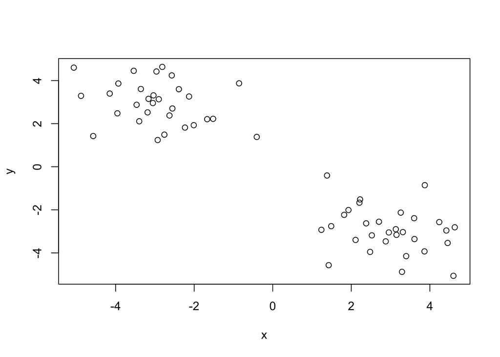

```r
# This creates two columns - Points that are (3,-3) and (-3, 3)
x <- cbind(x=tmp, y=rev(tmp))
# Plot a graph of the two columns
plot(x)
```

Now that we have made up data in ‘x’, we will see what kmeans() does to the data

```r
# We will use the function kmeans() to create 2 clusters, with 20 iterations (i.e. it is running through the algorithim 20 diff times)
k <- kmeans(x, centers = 2, nstart = 20)
k
```

```
## K-means clustering with 2 clusters of sizes 30, 30
##
## Cluster means:
##           x         y
## 1 -2.935596  2.952421
## 2  2.952421 -2.935596
##
## Clustering vector:
##  [1] 1 1 1 1 1 1 1 1 1 1 1 1 1 1 1 1 1 1 1 1 1 1 1 1 1 1 1 1 1 1 2 2 2 2 2 2 2 2
## [39] 2 2 2 2 2 2 2 2 2 2 2 2 2 2 2 2 2 2 2 2 2 2
##
## Within cluster sum of squares by cluster:
## [1] 62.26025 62.26025
##  (between_SS / total_SS =  89.3 %)
##
## Available components:
##
## [1] "cluster"      "centers"      "totss"        "withinss"     "tot.withinss"
## [6] "betweenss"    "size"         "iter"         "ifault"
```

When we print k, 2 clusters are created, with each cluster containing 30 points each. It also tells us our cluster means, which are the (x, y) coordinates of the means of the 2 clusters.

There are different available components that can help us learn more about the cluster.

> Q. How many points are in each cluster?

```r
k$size
```

```
## [1] 30 30
```

> Q. How do we get to the cluster membership/assignment?

```r
k$cluster
```

```
##  [1] 1 1 1 1 1 1 1 1 1 1 1 1 1 1 1 1 1 1 1 1 1 1 1 1 1 1 1 1 1 1 2 2 2 2 2 2 2 2
## [39] 2 2 2 2 2 2 2 2 2 2 2 2 2 2 2 2 2 2 2 2 2 2
```

> Q. What about cluster centers?

```r
k$centers
```

```
##           x         y
## 1 -2.935596  2.952421
## 2  2.952421 -2.935596
```

Now that we have returned the main results of our clusters, we will use them to generate a plot of our kmeans().

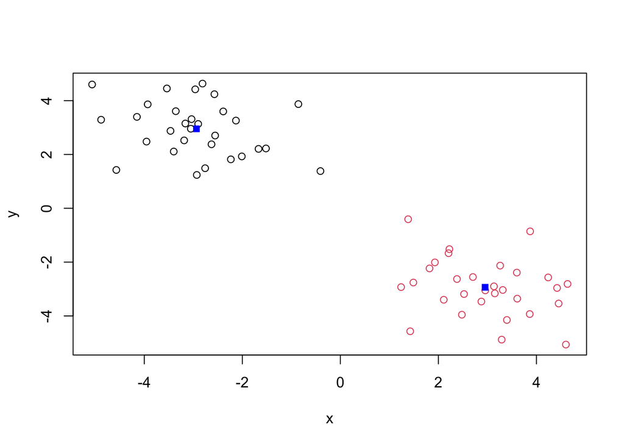

```r
# To color the plot according to the cluster
plot(x, col=k$cluster)
# Ti distinguish the center value of each cluster with different color, in this case, blue
points(k$centers, col="blue", pch=15)
```

## Now for hclust()

We will cluster the same data ‘x’ with the `hclust()` function. In this case `hclust() requires a distance matrix as an input.

```r
hc <- hclust(dist(x))
hc
```

```
##
## Call:
## hclust(d = dist(x))
##
## Cluster method   : complete
## Distance         : euclidean
## Number of objects: 60
```

Let’s plot our hclust result!

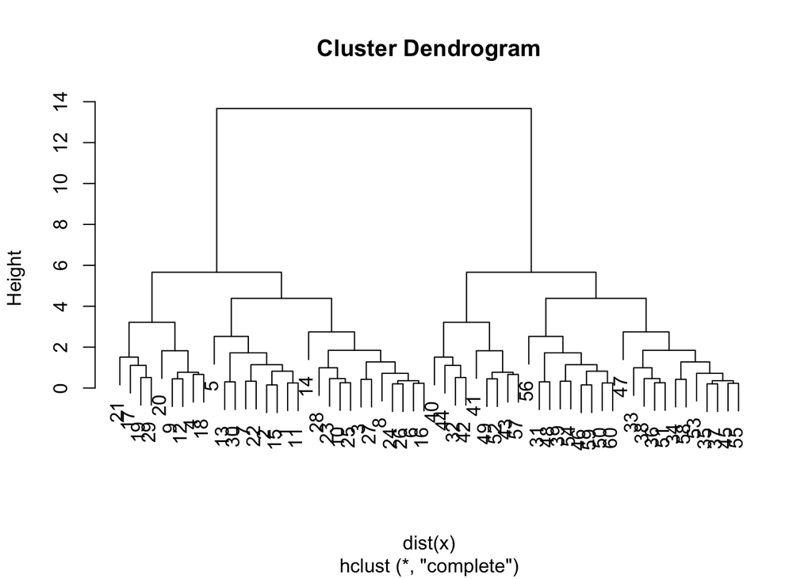

```r
plot(hc)
```

To get our cluster membership vector we need to “cut” the tree with `cutree()`

```r
groups <- cutree(hc, h=8)
groups
```

```
##  [1] 1 1 1 1 1 1 1 1 1 1 1 1 1 1 1 1 1 1 1 1 1 1 1 1 1 1 1 1 1 1 2 2 2 2 2 2 2 2
## [39] 2 2 2 2 2 2 2 2 2 2 2 2 2 2 2 2 2 2 2 2 2 2
```

Now plot our data with the hclust() results.

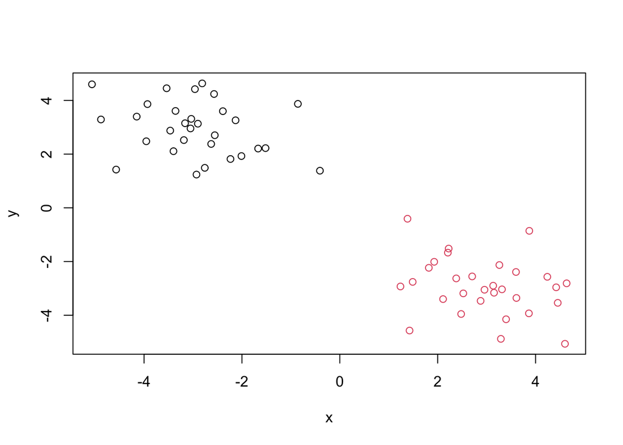

```r
plot(x, col=groups)
```